# BIOL432_A8

Jennah Levac

2025-03-03

Jennah Levac (20169998), Grace Wolfe (20302888), Harnaaz Sandhu (20258736), Kyle Samson (20294258), Aidan McLeod (20294254)

Gituhb Link: https://github.com/Jennah2882/BIOL432_A8

```r
library(ape)
library(ggplot2)
library(ggtree)
library(viridis)
library(reshape2)
```

#### Appending our dragons to the existing nexus file

```r
nexusFile <- "DragonMatrix.nex"
nexusLines <- readLines(nexusFile)
Entries <- c(
  "75BritishX 100100110000100110000000001110100001001010000000011000010001011100001010011100",
  "76FrenchXX 111100011100000101000100010000010000000000001100000000100000111111100001100001",
  "77DanishXX 10011111000010010010010010100010100000000110000001100001????0111100???11100001")

End <- which(nexusLines == ";")
nexusLines <- append(nexusLines, Entries, after = End - 1)
Final<- gsub("ntax=77", paste0("ntax=80"), nexusLines)
writeLines(Final, "UpdatedDragonMatrix.nex")
```

#### Create vector of weights

```r
WeightsData<-read.csv("Weights.csv")
Weights<-paste0(WeightsData$Weight,collapse="")
Weights<-strsplit(Weights,split="")[[1]]
```

#### Custom function to convert *letters* to corresponding numeric weight values

```r
WeightsNum<-rep(NA,length(Weights))
for(i in 1:length(WeightsNum))
  {if(Weights[i] %in% LETTERS){
    WeightsNum[i]<-which(LETTERS==Weights[i])+9
    } else {
      WeightsNum[i]<-Weights[i]}}
WeightsNum<-as.numeric(WeightsNum)
```

```r
WtDragon <- read.nexus.data("UpdatedDragonMatrix.nex")
```

#### Multiply weight by trait vector for each dragon

```r
for (i in 1:length(WtDragon)){
  RepWeight<-WtDragon[[i]]==1
  WtDragon[[i]][RepWeight]<-WeightsNum[RepWeight]
  RepWeight<-NA}
```

```r
WtDragonDF<-data.frame(matrix(unlist(WtDragon),ncol=78,byrow=T))
row.names(WtDragonDF)<-names(WtDragon)
```

#### Distance matrix

```r
WtDragonDist<-dist(WtDragonDF,method='euclidean')
WtDragonDistMat<-as.matrix(WtDragonDist)
```

```r
PlotSet<-melt(WtDragonDistMat)
names(PlotSet)<-c("Query","Subject","Distance")
```

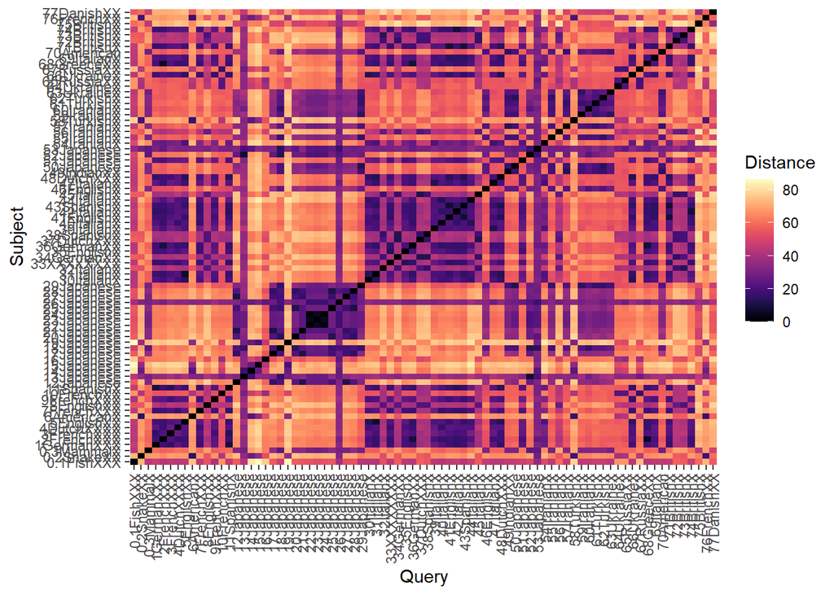

```r
ggplot(data = PlotSet, aes(x=Query, y=Subject, fill=Distance)) +geom_tile() +scale_fill_viridis(option="magma") +theme(axis.text.x = element_text(angle = 90, hjust = 1, vjust = 0.5))
```

**Figure 1**: Visualization of the distance matrix which measures the genetic distance between each dragon. Distances closer to 0 indicate more closely related dragons.

#### Dragon images and source

[figure not shown]

British

[figure not shown]

French

[figure not shown]

Danish

Link: https://www.pinterest.com/pin/229331806013911066/

#### Phylogeny by country of origin

```r
WtDragonTree<-nj(WtDragonDist)
```

```r
Country<-gsub("[0-9\\.]+([^X]+)X*","\\1",WtDragonTree$tip.label)
CountryGroups<-split(WtDragonTree$tip.label, Country)
WtDTcol<-groupOTU(WtDragonTree,CountryGroups)
Tree<- ggtree(WtDTcol,layout="rectangular",aes(colour=group)) +geom_tiplab(size=2)
```

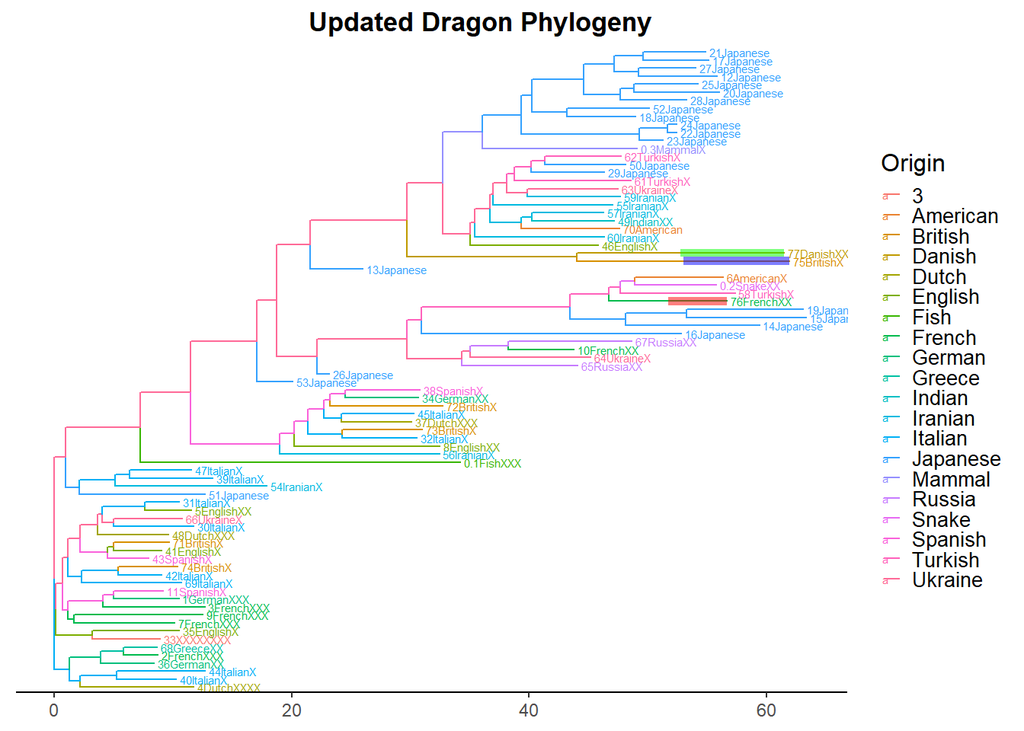

```r
highlight <- c("British" = "blue", "French" = "red", "Danish" = "green")
tip_labels <- WtDragonTree$tip.label
highlight_tips <- c("75BritishX", "76FrenchXX", "77DanishXX")
highlight_nodes <- which(tip_labels %in% highlight_tips)

Tree +
  geom_hilight(node = highlight_nodes[1], fill = highlight["British"], alpha = 0.5) +
  geom_hilight(node = highlight_nodes[2], fill = highlight["French"], alpha = 0.5) +
  geom_hilight(node = highlight_nodes[3], fill = highlight["Danish"], alpha = 0.5) +
  theme_tree2() +
  ggtitle("Updated Dragon Phylogeny") +
  theme(plot.title = element_text(hjust = 0.6, face = "bold"), legend.text = element_text(size = 10), legend.title = element_text(size = 12), legend.key.size = unit(10, "pt")) + labs(color= "Origin")
```

**Figure 2**: Final dragon phylogeny which includes our French, British, and Danish dragon lineages highlighted in red, blue, and green, respectively.

#### Backstory

During medieval times there were tales of epic quests and legendary dragons roaming the lands freely, with the most fearsome of these dragons hailing from Britain, Denmark, and France. Their names were spoken in whispers of awe, for their power could turn the tide of wars and destroy entire realms. Centuries later, ancient documents and relics depicting these creatures were uncovered. Upon further inspection, bones from multiple dragon lineages were discovered, allowing DNA to be successfully isolated from the bones and used to trace the genetic lineages of these dragons.

#### Data Interpretation

The heat map shown in **Figure 1** that 77DanishXX and 75BritishX have a relatively small genetic distance (~20-40, light purple). Alternatively, the 76FrenchXX lineage falls within the 60-80 salmon colored distance range for both the Danish and British lineages, indicating it is less genetically similar. However, the French lineage does show a slightly closer genetic relation to the Danish line than the British line.

Based on the phylogenetic tree in **Figure 2**, the 77DanishXX and 75BritishX lineages are the two most closely related lineages out of the three and diverged from a common ancestor. On the other hand, the 76FrenchXX dragon is placed more distantly from both the British and Danish dragons, suggesting that its evolutionary history diverged at a different point from the common shared ancestor between the three lineages. This difference may have been due to environmental pressures that resulted in the natural selection of traits that provide an advantage in that environment. For example, lateral eye positioning may be a more useful trait for a sea dragon (French) than land dragon (forward eye positioning– British + Danish). This led to the differentiation between dragons of different regions, and contributed to the variance in physiology of dragons as depicted in works of art from around the world.